# Guide to Downloading Course Materials

Course materials are located in the main course repository on [Github](https://github.com/robbinscalebj/QuantBio_BIO5324_Sp2026), but it’s a pain to download these files one by one into your downloads folder and then copy/paste from there into your working directory.

Here are two ways to download the Lecture and Problem Sets folders in a more batched manner. Use whichever you prefer. These instructions apply to either the Lectures or the Problem Sets.

## Downloading materials with bash

bash is a scripting language that is primarily run in your computer’s terminal, if it’s Mac or Linux-based. It also runs in the Terminal that RStudio has in the Console pane, even on Windows - just select the Terminal tab and you’ll see the prompts appear and should show your user as currently in your RProject’s directory.

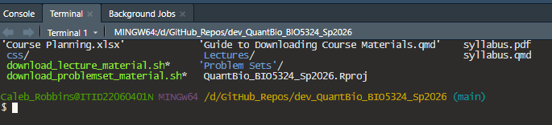

Here’s what the terminal looks like when the prompt is ready for use

We can use shell scripts to download the material we want. Note this is not R code, we’re just able to run these in RStudio. The bash code is the quickest way to grab folders you need, so long as I’ve posted them already on the main course repo…

Step 1: *Check your working directory.* Make sure your RProject is open (the name of the project should show up in the very upper right of RStudio).

You should see your RProject name in the upper right corner whenever you are working on this class material, as good practice

Step 2: *Check that the script file exists in the appropriate spot.* Make sure you have the file “download_lecture_material.sh” (or download_problemset_material.sh) in the top directory of your RProject directory. Easiest way to do this is see if it pops up when you run list.files(). Here’s what mine looks like and I can see both in the list:

```r
list.files()
```

```
 [1] "Analysis Presentation"
 [2] "Course Planning.xlsx"
 [3] "css"
 [4] "download_lecture_material.sh"
 [5] "download_problemset_material.sh"
 [6] "Figures"
 [7] "Guide-to-Downloading-Course-Materials.rmarkdown"
 [8] "Guide to Downloading Course Materials.html"
 [9] "Guide to Downloading Course Materials.qmd"
[10] "Guide to Downloading Course Materials.rmarkdown"
[11] "Lectures"
[12] "Problem Sets"
[13] "QuantBio_BIO5324_Sp2026.Rproj"
[14] "README.md"
[15] "README.qmd"
[16] "syllabus.pdf"
[17] "syllabus.qmd"
```

Step 3: **Edit the script.** You need to change the number of the lecture or problem set you want to download in the file *download_lecture_material.sh*. Where to edit this number in the script is marked in the top of the .sh file (right now, it just says “02”, which would grab the 02_Intro-to-R lecture materials). The best way to do this is to click on it in your Files pane (lower right), which will open it up into this Source pane where you can edit the text. Simply change the number to 01, 02, 10, whatever you need. **MAKE SURE TO SAVE IT** (CTRL + s).

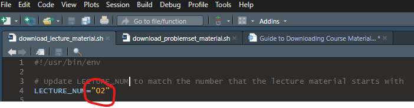

Simply edit the “02” here to be the Lecture or Problem Set number you need, then save

Step 4: **Run the script.** Open the Terminal tab in the Console pane of RStudio. Type the following into the prompt (or copy and right-click+Paste) to run your edited and saved shell script: bash download_lecture_material.sh OR bash download_problemset material.sh, depending on what you wanted. Note that this script should not overwrite files if you accidentally download them twice. You also might be able to just double click on the scripts in Explorer after you’ve edited them. Not sure how Windows will deal with them on your machine.

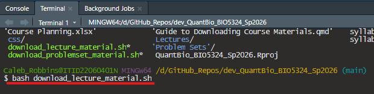

Enter bash and then the name of your edited script into the terminal

Step 5: **Check that it worked.** Look for the new lecture materials in the Lectures/ folder of your directory. Look for the new Problem Set materials in the Problem Sets/ folder of your directory.

## Downloading materials with Github’s web-based editor

It turns out Github also has a [VS Code editor](https://docs.github.com/en/codespaces/the-githubdev-web-based-editor) for repositories, which enables some nifty stuff, including direct point-and-click download of files.

Step 1: **Go to the Github.dev course repo.** Instead of https://github.com/robbinscalebj/QuantBio_BIO5324_Sp2026, exchange ‘.com’ for ‘.dev’. https://github.dev/robbinscalebj/QuantBio_BIO5324_Sp2026. Accept any prompts Github might give you.

Step 2: **Find the course folder/materials you want to download.** Look in the Explorer pane on the left side, under Lectures and Problem Sets.

Step 3: **Select and download materials.** Right click on the folder (or files) you want and click “Download.” Then you can select where you want these to go (it should be in your RProject directory’s “Lectures” folder or “Problem Sets” folder, as appropriate)

[figure not shown]

.